Saltar al contenido principal

**National University of the Altiplano** **Faculty of Statistical Engineering and Computer Science** **Theacher:** Fred Torres Cruz **Authors:** Roberth Carlos GONZALES MAURICIO.  
Cesia Belén GÓMEZ FLORES.

**Acceso al crédito agrario en el Perú: a quién priorizar y qué acciones impulsar (ENA 2016–2025)**

# 1 Objetivo

Identificar qué pequeños y medianos productores agropecuarios tienen más probabilidad de acceder al crédito, dónde están los que tienen perfil de prestatario pero no lo piden y qué condiciones se asocian con un mayor acceso, para orientar a entidades financieras y programas públicos. Es un informe reproducible: todas las cifras se calculan en R al renderizarlo con Quarto, a partir de los datos y de los resultados de los scripts.

# 2 Datos y método

**Datos.** 49,837 productores de la Encuesta Nacional Agropecuaria (ENA) del INEI, rondas 2016, 2017, 2019 y 2022–2025, sorteados por conglomerados completos de 196,566 productores depurados. La variable objetivo vale 1 si el productor solicitó crédito en los últimos 12 meses y lo obtuvo (preguntas P901 y P902); el 11.9 % de la muestra lo tiene (10.1 % ponderado). Entrenamiento y prueba se separan por conglomerado, para que ningún vecindario quede en ambos lados.

**Método.** De 35 variables candidatas se eligieron 14 con importancia SHAP en validación cruzada, eliminación de redundantes y la regla de un error estándar. El modelo es XGBoost con `caret`, ajustado con 40 combinaciones de hiperparámetros y validación cruzada agrupada; se comparó con una regresión logística (`easystats`), una logística elastic net, un bosque aleatorio y un modelo aditivo. Con el modelo final se analizaron la focalización, la brecha de propensión, los prestamistas (pregunta P903) y escenarios hipotéticos.

# 3 Resultados

## 3.1 Qué tan confiable es el modelo

Desempeño de cinco modelos en el conjunto de prueba (intervalo de confianza bootstrap del AUC-ROC)

| Modelo | AUC-ROC | IC 95 % | AUC-PR | Brier |
| --- | --- | --- | --- | --- |
| XGBoost | 0.798 | 0.780–0.814 | 0.367 | 0.089 |
| Logística | 0.791 | 0.774–0.807 | 0.359 | 0.090 |
| Logística elastic net | 0.791 | 0.774–0.807 | 0.360 | 0.090 |
| Bosque aleatorio | 0.794 | 0.775–0.810 | 0.354 | 0.090 |
| GAM | 0.796 | 0.779–0.812 | 0.371 | 0.089 |

XGBoost alcanza un AUC-ROC de 0.798 y un AUC-PR de 0.367, tres veces la prevalencia (0.119). Se mantiene al entrenar con 2016–2023 y probar en 2024–2025 (0.804) y con los 196,566 productores depurados (0.801). Está bien calibrado (pendiente 1.04; en el decil superior predice 42.0 % y ocurre 42.7 %). Los cinco modelos rinden casi igual: lo que limita la precisión es la información de la encuesta, no el algoritmo.

## 3.2 Qué se asocia con tener crédito

Según el modelo, pertenecer a una asociación suma 7.1 puntos porcentuales a la probabilidad de tener crédito; pasar del primer al tercer cuartil de superficie cosechada, 6.0; y usar fertilizantes, 4.1. La edad es el único factor que resta (-2.6). En la regresión logística, estar asociado multiplica por 2.12 las *odds* de tener crédito (intervalo robusto 1.89–2.37) y usar fertilizantes por 1.62; cada década de edad las reduce a 0.83. Son asociaciones, no efectos causales.

## 3.3 A quién priorizar y dónde está la brecha

Ordenando a los productores por su probabilidad, el 10 % superior reúne al 36 % de quienes tienen crédito y el 20 % superior al 54 %: 3.6 veces más eficiente que elegir al azar.

**El acceso depende de solicitar.** Solo el 13.0 % de los productores pidió crédito y al 91.9 % de ellos se lo dieron. El 16.4 % no tiene crédito aunque el modelo le da una probabilidad alta (la **brecha de propensión**), pero apenas el 1.9 % de ese grupo solicitó. La barrera está antes de pedir crédito, no en la aprobación. La brecha es mayor donde el crédito ya es frecuente (correlación 0.98), así que señala dónde promover solicitudes es más fácil.

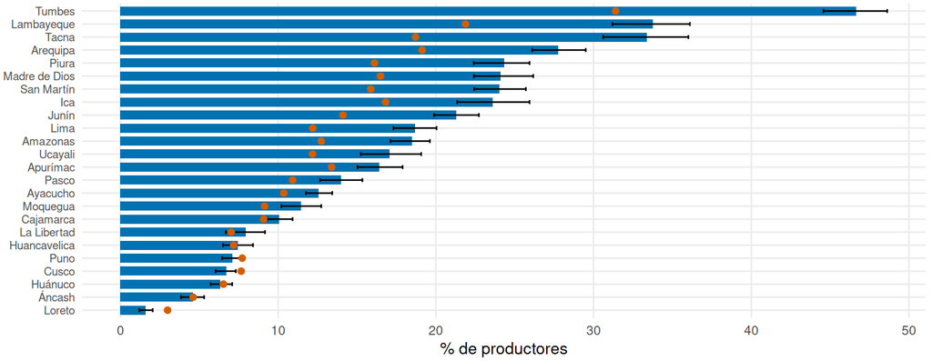

Figura 1: Brecha de propensión (barras, con IC 95 %) y tasa de crédito (puntos) por departamento, con los 196,566 productores depurados

## 3.4 Quién presta

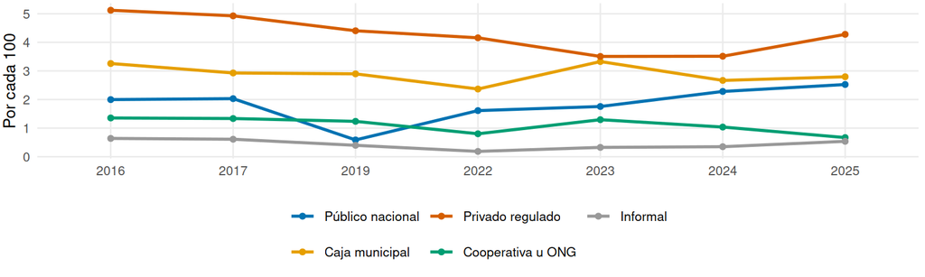

Figura 2: Prestatarios de cada tipo por cada 100 productores (ponderado)

Los prestamistas privados regulados (bancos, cajas rurales y financieras) son la fuente principal. El crédito público (Agrobanco y programas del Estado) cayó de 2.0 a 0.6 prestatarios por cada 100 productores entre 2017 y 2019, durante la crisis de Agrobanco, y **nadie lo reemplazó**: en los productores con perfil de cliente de Agrobanco, el acceso cayó de 18.2 % a 14.3 % y el crédito de otros prestamistas no subió (12.7 % y 12.9 %). El crédito público llega sobre todo a los asociados (*odds* 2.33 veces mayores que en el privado). En Lambayeque el 31 % de los prestatarios usa prestamistas informales, y en Apurímac el 47 % usa cooperativas.

## 3.5 Qué acciones probar

Si todos los no asociados se asociaran, la tasa nacional ponderada simulada pasaría de 10.3 % a 16.4 %. El riego (+3.6 puntos) y los fertilizantes (+2.3) solo suman de forma clara en la selva. Con presupuesto para asociar a 1,000 productores, elegir a los no asociados con mayor probabilidad logra 103 nuevos accesos esperados frente a 65 al azar, evaluado con un modelo independiente. Son simulaciones del modelo: indican dónde probar, no cuánto crédito se crearía.

# 4 Líneas de acción

1. **Focalizar con el modelo:** dirigir la colocación al 20 % de productores con mayor probabilidad, que reúne a más de la mitad de los prestatarios.
2. **Bajar el costo de pedir crédito:** la brecha casi no solicita y la denegación es rara (8 %); probar información, trámites simples y productos a través de organizaciones, empezando por Tumbes, Lambayeque y Tacna.
3. **Usar la asociatividad como canal,** con pilotos evaluables.
4. **Dar estabilidad al crédito público:** cuando Agrobanco se retiró, sus clientes no fueron atendidos por otros.
5. **En la selva, combinar crédito con riego e insumos.**

# 5 Limitaciones

Los datos son observacionales: los escenarios describen asociaciones del modelo, no efectos causales. La precisión es 0.30, útil para priorizar grupos pero no casos individuales. La encuesta no informa por qué los productores no solicitan ni sobre la cercanía de las agencias financieras.

# 6 Reproducibilidad

El análisis se hace íntegramente en R y se reproduce en Positron: abrir la carpeta del proyecto, ejecutar en orden los scripts `R/00_paquetes.R` a `R/15_exportar_csv.R` (unos 15 minutos) y renderizar este archivo con el botón **Preview** o con `quarto render R/informe/informe_reproducible.qmd`. Versiones: R 4.6.1, xgboost 3.2.1.1, caret 7.0.1, easystats 0.7.6, tidyverse 2.0.0. Código y datos: github.com/ROBERTHGONZALES/credito-agro-ena-r.